# GEE DSM regression in R

Trevan Flynn

2023-05-24

load libraries needed

```r
library(sf)
library(tidyverse)
library(yardstick)
library(ggpubr)
library(rgee)
ee_Initialize()
```

```
## ── rgee 1.1.5 ─────────────────────────────────────── earthengine-api 0.1.323 ──
##  ✔ user: not_defined
##  ✔ Initializing Google Earth Engine:
 ✔ Initializing Google Earth Engine:  DONE!
##
 ✔ Earth Engine account: users/trevanflynn
## ────────────────────────────────────────────────────────────────────────────────
```

labels response and scales (will be used later) and load boundaries

```r
#labels
label = "phaq_val_1" #response (how it is in the database)
scale = 30 #resolution of output
tileScale = 4 #factor to reduce region of computation (0-16)

#Get Otjozondjupa province in Namibia
worldProvince = ee$FeatureCollection("FAO/GAUL_SIMPLIFIED_500m/2015/level1"); #admin
filterProvince = ee$Filter$eq('ADM1_NAME', 'Otjozondjupa'); #select province
region = worldProvince$filter(filterProvince); #filter to area

#load WoSIS data of pH (point observations)
collection = ee$FeatureCollection("users/trevanflynn/WoSIS_pH")$
  select(label)$#select pH (response)
  filterBounds(region)$ #clip to region
  filter(ee$Filter$lt(label, 10))#remove outlier (one sample is above 10)

#check data
Map$centerObject(region, 6)
```

```
## NOTE: Center obtained from the first element.
```

```r
Map$addLayer(collection)
```

[interactive chart not shown]

Create covariate image (climatic data - 19 bioclim variables at www.worldclim.org) and sample data from WoSIS collection. Similar to extract in terra or stars package. We then add x and y to add neighboorhood covariates.

If image collection is made to represent the scorpan factors, convert to an image with ImageCollection$toBands(). This is common in some datasets and is usually needed when collecting covariates.

```r
#image  = coStack$toBands()
#get worldclim biovariables (already in image format)
coStack = ee$Image("WORLDCLIM/V1/BIO")$#get climate data
  clip(region)$#clip to region
  addBands(ee$Image$pixelLonLat())#add x and y as covariates

#resample at resolution desired
coStack = coStack$
  reproject(crs = "EPSG: 3857", scale = scale)$ #sample to 30 m
  resample(mode = 'bicubic') #set resampling mode

#sample covariates at observations
samples = coStack$sampleRegions(
  collection = collection, #collection with response
  properties = list(label),
  scale = scale,
  geometries = T)$
  randomColumn() #add random column for making training/test set

#split data
training = samples$filter(ee$Filter$gt('random',0.2)) # 80% training
validation = samples$filter(ee$Filter$lte('random',0.2)) # 20% testing

#predictor variable names
bands = coStack$bandNames()
```

Regression classifier, must build the model and and set the mode to “REGRESSION” before training the model. For gradient tree boosting (GTB) you only need to specify number of trees to grow.

Default values for GTB: -shrinkage = 0.005 (lower = less over fitting but slower) -samplingRate = 0.7 (bag fraction for each tree) -maxNodes = Inf (max nodes in each tree) -loss = “LeastAbsoluteDeviation” (objective function) -seed = 0 (replicate results)

```r
#build and train
rfReg= ee$Classifier$smileGradientTreeBoost( #model
  numberOfTrees = 500, #500 trees
  shrinkage = 0.1)$#higher shrinkage = lower time needed (overfits easier)
  setOutputMode("REGRESSION")$ #(default = classification)
  train(features = training,
        classProperty = label,
        inputProperties = bands)

#predict trained RF model over covariate image
pHmap = coStack$classify(rfReg, "predictions")

#plot results
Map$centerObject(region, 6)#center map
```

```
## NOTE: Center obtained from the first element.
```

```r
Map$addLayer(pHmap, list(min = 7, max = 9, palette = c("blue", "red", "yellow", "green", "grey")))
```

[interactive chart not shown]

Evaluate predictions (easiest to convert to sf if small area)

```r
#set metrics (a bunch in the yardstick library), example shown for common DSM metics
met = metric_set(ccc, rsq, rmse)#lins coefficient, R2 and RMSE

#predict and convert to sf object
eval = validation$classify(rfReg, "predictions")$ #predict
  select(label, "predictions")%>% #select response and predictions (lower computation)
  ee_as_sf() #convert
#print results
eval %>%
  met(phaq_val_1, predictions)
```

```
## # A tibble: 3 × 4
##   .metric .estimator .estimate                                          geometry
##   <chr>   <chr>          <dbl>                                  <MULTIPOINT [°]>
## 1 ccc     standard       0.549 ((16.19999 -20.88327), (16.25012 -20.7001), (19.…
## 2 rsq     standard       0.314 ((16.19999 -20.88327), (16.25012 -20.7001), (19.…
## 3 rmse    standard       0.817 ((16.19999 -20.88327), (16.25012 -20.7001), (19.…
```

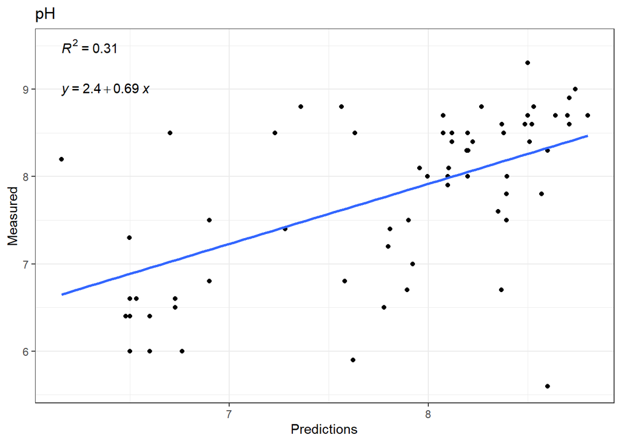

```r
#plot reg line and other stats
#R2 and regline plot
ggplot(data = eval, aes(y = phaq_val_1, x = predictions))+
  geom_point()+
  geom_smooth(method = 'lm', se = F)+
  stat_cor(label.y= 9.5, aes(label = after_stat(rr.label)))+
  stat_regline_equation(label.y = 9)+
  labs(x = "Predictions", y = "Measured", title = "pH")+
  theme_bw()
```

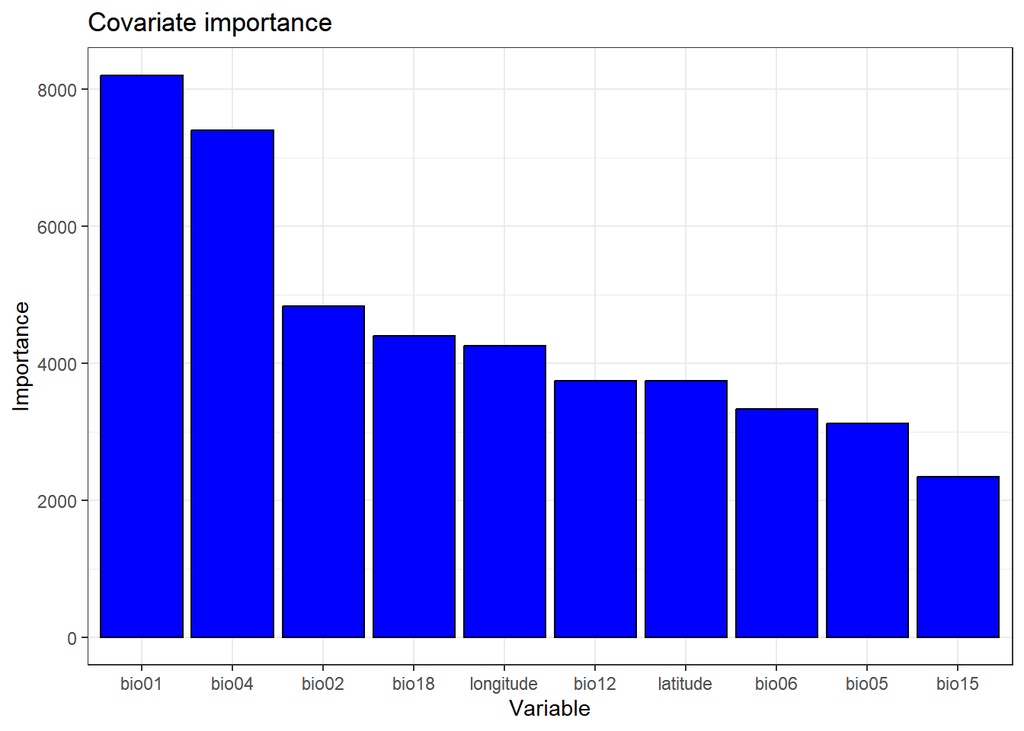

```r
#covariate importance for top 10
varImp = rfReg$explain()$get("importance")$getInfo()%>% #get importance
  as_tibble()%>%#make tibble
  pivot_longer(cols = c(1:ncol(.)))%>% #long df for plotting
  arrange(desc(value))%>% #sort decreasing values
  slice(1:10) #get top 10

#plot
ggplot(data = varImp, aes(x = reorder(name, -value), y = value))+
  geom_bar(stat ="identity", color = 'black', fill = 'blue')+
  labs(x = "Variable", y = "Importance", title = "Covariate importance")+
  theme_bw()
```

To save or for further analysis, convert to stars object or export to google drive. Converting to stars will save and load into memory but can take a long time

[output not shown]